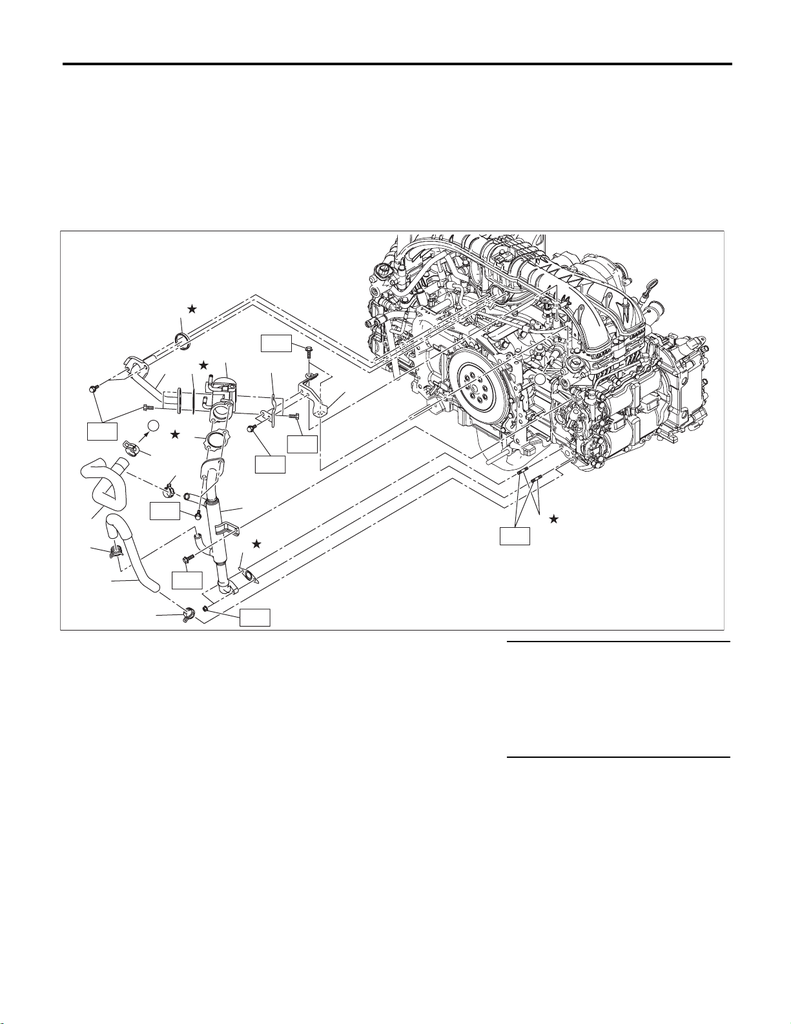

EC(w/o STI)-2

General Description

EMISSION CONTROL (AUX. EMISSION CONTROL DEVICES)

1. General Description

A: COMPONENT

1. CANISTER, PURGE CONTROL SOLENOID VALVE, AND LEAK CHECK VALVE ASSEM-

BLY

For components of canister, purge control solenoid valve, and leak check valve assembly, refer to FU(w/o

STI). <Ref. to FU(w/o STI)-3, COMPONENT, General Description.>

(1) O-ring (8) EGR cooler Tightening torque: N·m (kgf-m, ft-lb)

(2) EGR pipe (9) Clip T1: 6.4 (0.7, 4.7)

(3) Gasket (10) Water hose A T2: 19 (1.9, 14.0)

(4) EGR control valve (11) Water hose B (MT model) T3: <Ref. to EC(w/o STI)-33,

INSTALLATION, EGR Pipe.>

(5) EGR control valve bracket A (12) Gasket T4: <Ref. to EC(w/o STI)-43,

INSTALLATION, EGR Cooler.>

(6) EGR control valve bracket B (13) Stud bolt

(7) Gasket

EC-03437

(9)

T2

T3

T1

T1

T4

T2

(13)

T1

A

(9)

(9)

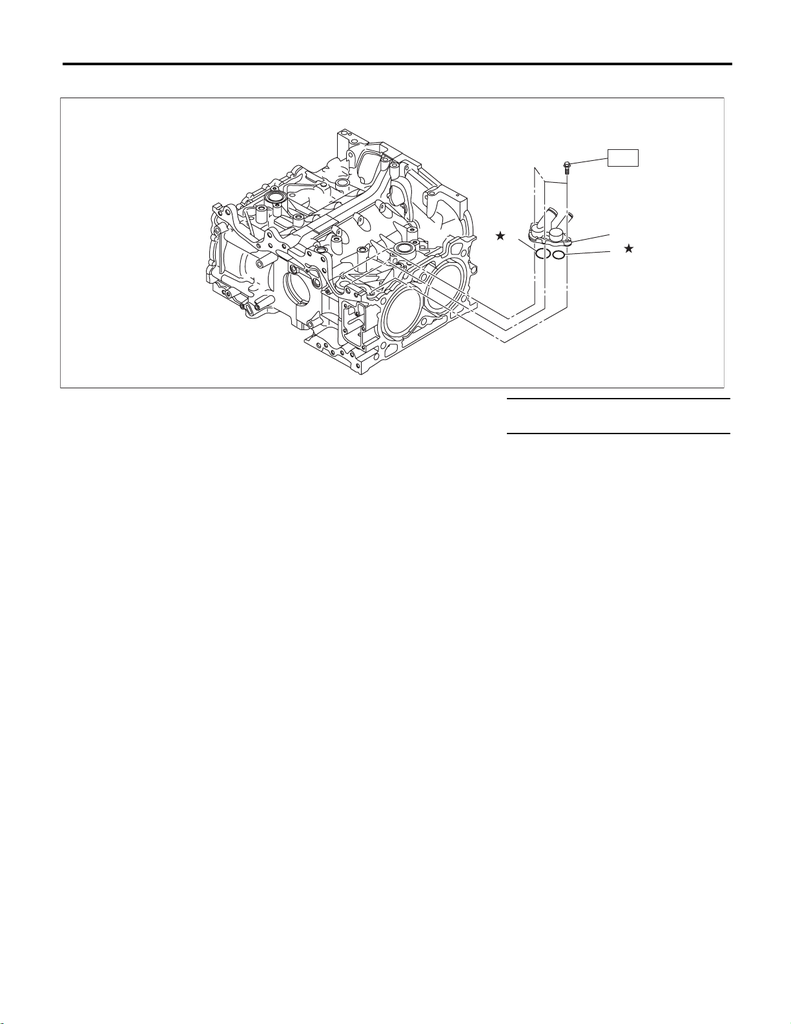

EC(w/o STI)-3

General Description

EMISSION CONTROL (AUX. EMISSION CONTROL DEVICES)

3. PCV SYSTEM 1

(1) PCV connector (3) O-ring Tightening torque: N·m (kgf-m, ft-lb)

(2) O-ring T: 6.4 (0.7, 4.7)

EC-03219

(3)

(2)

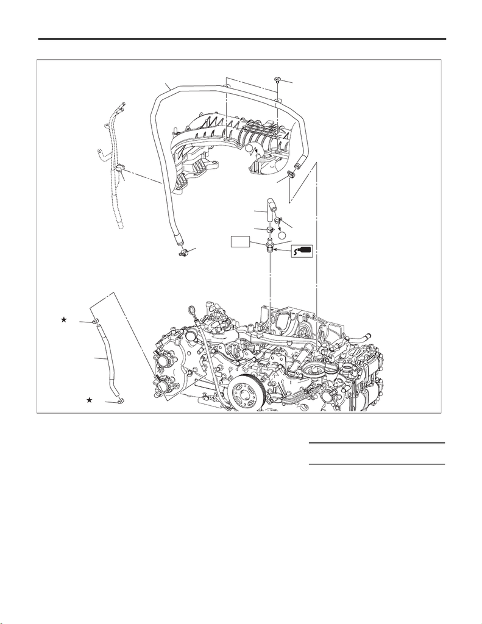

EC(w/o STI)-4

General Description

EMISSION CONTROL (AUX. EMISSION CONTROL DEVICES)

4. PCV SYSTEM 2

(1) PCV pipe (6) Clip (11) Clamp

(2) Clip (7) Clip

(3) Clip (8) PCV valve Tightening torque: N·m (kgf-m, ft-lb)

(4) Clip (9) Clip T: 23 (2.3, 17.0)

(5) PCV hose A (10) PCV hose B

T

A

A

(4)

(1)

(7)

(10)

(11)

(6)

(2)

(3)

EC-03316

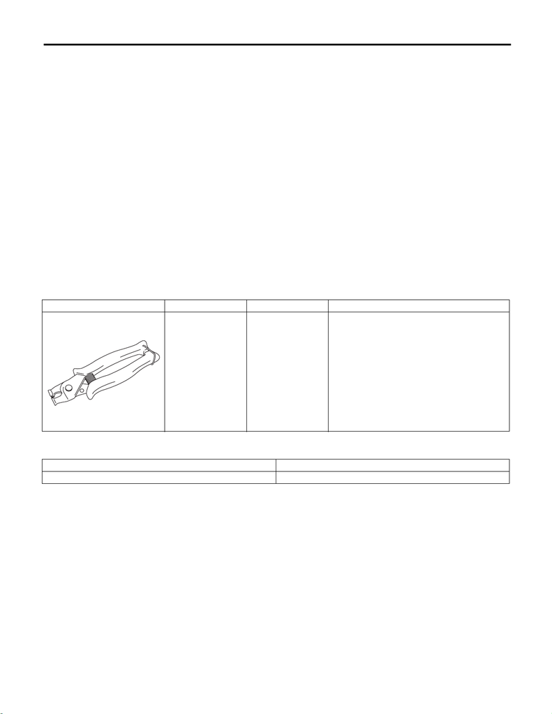

EC(w/o STI)-5

General Description

EMISSION CONTROL (AUX. EMISSION CONTROL DEVICES)

B: CAUTION

• Prior to starting work, pay special attention to the following:

1. Always wear work clothes, a work cap, and protective shoes. Additionally, wear a helmet, protective

goggles, etc. if necessary.

2. Protect the vehicle using a seat cover, fender cover, etc.

3. Prepare the service tools, clean cloth, containers to catch grease and oil, etc.

• Vehicle components are extremely hot immediately after driving. Be wary of receiving burns from heated

parts.

• When performing a repair, identify the cause of trouble and avoid unnecessary removal, disassembly and

replacement.

• Before disconnecting connectors of sensors or units, be sure to disconnect the ground cable from battery.

• Always use the jack-up point when the shop jacks or rigid racks are used to support the vehicle.

• Remove contamination including dirt and corrosion before removal, installation, disassembly or assembly.

• Keep the removed parts in order and protect them from dust and dirt.

• All removed parts, if to be reused, should be reinstalled in the original positions with attention to the correct

directions, etc.

• Bolts, nuts and washers should be replaced with new parts as required.

• Be sure to tighten the fasteners including bolts and nuts to the specified torque.

C: PREPARATION TOOL

1. SPECIAL TOOL

2. GENERAL TOOL

ILLUSTRATION TOOL NUMBER DESCRIPTION REMARKS

18353AA000 CLAMP PLIERS • Used for removing and installing the PCV hose

assembly.

• This tool is made by the French company

CAILLAU. (code) 54.0.000.205

To make it easier to obtain, it has been provided

with a tool number.

TOOL NAME REMARKS

Circuit tester Used for measuring resistance and voltage.

ST18353AA000